# Lecture 7：データを意思決定に使う

個人の好みからターゲティング・顧客価値・コンジョイントへ｜計量経済学II

作者

Kei Ikegami

**重要この講義で押さえたいこと**

- 第6回で求めた「各タイプである確率」を使い、個人ごとの選択確率と期待利益を計算する。
- ターゲティングでは、クーポンあり・なしの利益を、同じ個人の事後分布で比較する。
- 顧客価値では、同じ選択モデルから得た将来利益を、期間を通じて足し合わせる。
- コンジョイントでは、属性と価格を変えた選択質問を作り、回答から好みを学んで商品設計に使う。
- モデルで決めた施策は、学習に使っていない実験で利益と不確実性を確かめる。

## 前回とのつながり・今回の問い

第6回では、母集団の好みの分布と本人の選択履歴を組み合わせ、「この人が苦味好きである確率」「中間のタイプである確率」「甘味好きである確率」を求めた。本人のタイプを一つに断定せず、分布として残すところまでが前回だった。今回は、**その分布が分かると、企業は何を判断できるのか**を考える。

同じコーヒー店の担当者が、Aのクーポンを誰に送るか、今後半年の顧客価値はいくらか、Aの味と価格をどう変えるか、を検討している。三つとも、個人が各商品を選ぶ確率を利益に結びつける問題である。ターゲティングと顧客価値は同じ購買履歴・同じ推定結果を使う。最後のコンジョイントでは、選択履歴を調査によって新たに作り、同じ推定と予測の考え方を使う。

第6回のファイルや保存済みの推定値は読み込まない。同じモデルをこのノート内で再現し、必要なデータを生成して推定する。主題を意思決定に絞るため、タイプの位置と共通の効用係数は既知とし、母集団のタイプ割合を推定する。第6回後半のように、それらも未知として推定する拡張は可能である。

## 1. 個人のタイプの分布から、次の選択確率へ

### 1.1 同じコーヒー選択モデルを使う

自社の苦いコーヒーA、甘いコーヒーB、「買わない」の3択である。甘さを $x_A=-1,x_B=1$ とし、個人 $i$ の機会 $t$ の効用を

$$u_{ijt}=1.5+\theta_i x_j-p_{jt}+\varepsilon_{ijt},\quad j=A,B,
\qquad u_{i0t}=\varepsilon_{i0t}$$

とする。価格は100円単位で、$p=3$ は300円である。購入の定数 $b_0=1.5$ と価格感応度 $\alpha=1$ は第6回と同じだ。タイプは $\vartheta=(-1.5,0,1.5)$ のいずれかで、一人のタイプは全期間を通じて固定される。$\theta=0$ は甘さ・苦さへの傾きがないタイプであり、購入意欲がゼロという意味ではない。

選択ショックは、タイプと独立で、個人・機会・選択肢を通じて独立な標準Gumbel分布に従う。したがって、$v_j(\theta)=1.5+\theta x_j-p_j$ と置けば、

$$P_j(\theta;p,x)=\frac{\exp v_j(\theta)}
{1+\exp v_A(\theta)+\exp v_B(\theta)},\quad j=A,B,
\qquad P_0(\theta;p,x)=\frac1{1+\exp v_A(\theta)+\exp v_B(\theta)}.$$

**同じ人でも毎回同じ商品を選ぶわけではない。** 固定されたタイプと、毎回変わる選択のショックを分けている。

```r
choice_prob <- function(theta, pA, pB, xA = -1, xB = 1) {
  va <- 1.5 + theta * xA - pA
  vb <- 1.5 + theta * xB - pB
  mx <- pmax(0, va, vb)
  ev <- cbind(exp(-mx), exp(va - mx), exp(vb - mx))
  ev / rowSums(ev)  # 列は「買わない、A、B」
}
theta_grid <- c(-1.5, 0, 1.5)
pi_true <- c(.25, .50, .25)
type_names <- c("苦味好き", "中間", "甘味好き")
draw_choice <- function(prob) {
  u <- runif(nrow(prob))
  as.integer(u > prob[, 1]) + as.integer(u > prob[, 1] + prob[, 2])
}
simulate_history <- function(n, periods, seed, conjoint = FALSE) {
  set.seed(seed)
  type <- sample(1:3, n, replace = TRUE, prob = pi_true)
  dat <- data.frame(id = rep(seq_len(n), each = periods),
                    t = rep(seq_len(periods), n))
  nr <- nrow(dat)
  dat$pA <- sample(c(2.5, 3, 3.5), nr, replace = TRUE)
  dat$pB <- sample(c(2.5, 3, 3.5), nr, replace = TRUE)
  dat$xA <- if (conjoint) sample(-1:1, nr, replace = TRUE) else rep(-1, nr)
  dat$xB <- if (conjoint) sample(-1:1, nr, replace = TRUE) else rep(1, nr)
  pr <- with(dat, choice_prob(theta_grid[type[id]], pA, pB, xA, xB))
  dat$y <- draw_choice(pr)
  list(data = dat, type = type)  # typeは答え合わせ用に別保存
}
```

### 1.2 履歴から、各タイプである確率を更新する

本人の履歴 $H_i$ には、毎回の提示価格・商品属性と、買わなかった機会を含む選択結果を記録する。観測した機会ではA・Bがどちらも選べたとする。購入された行しかないPOSデータだけでは、同じ尤度をそのまま使えない。今回は価格をタイプやショックと独立に無作為化し、購入しなかった機会も観測できる設定にする。

タイプ $k$ のもとでの履歴の尤度と、事後確率は、第6回と同じ

$$L_i(\vartheta_k)=\prod_{t=1}^{T_i}P_{y_{it}}(\vartheta_k;p_t,x_t),
\qquad
w_{ik}=\frac{\widehat\pi_k L_i(\vartheta_k)}
{\sum_{\ell=1}^3\widehat\pi_\ell L_i(\vartheta_\ell)}$$

である。母集団割合 $\pi$ は、学習用の顧客の履歴から $\sum_i\log\{\sum_k\pi_kL_i(\vartheta_k)\}$ を最大にして求める。**同じ人の選択確率を先に掛け、その後でタイプについて足す。** 毎回タイプを引き直すモデルにはしない。

以下は、Eステップで事後確率を求め、Mステップでその平均を母集団割合にする、第6回のEMである。計算には対数尤度を使い、小さい確率の積による丸め誤差を避ける。

```r
history_loglik <- function(dat) {
  sapply(theta_grid, function(theta) {
    pr <- with(dat, choice_prob(theta, pA, pB, xA, xB))
    lp <- log(pr[cbind(seq_len(nrow(dat)), dat$y + 1)])
    drop(rowsum(lp, dat$id, reorder = TRUE))
  })
}
posterior_weights <- function(loglik, pi) {
  z <- sweep(loglik, 2, log(pi), "+")
  z <- z - apply(z, 1, max)
  w <- exp(z)
  w / rowSums(w)
}
estimate_pi <- function(loglik, tol = 1e-10) {
  pi <- rep(1 / 3, 3)
  for (iter in 1:10000) {
    updated <- colMeans(posterior_weights(loglik, pi))
    if (max(abs(updated - pi)) < tol) return(updated)
    pi <- updated
  }
  stop("EM did not converge")
}
train <- simulate_history(1200, 6, 20260701)
pi_hat <- estimate_pi(history_loglik(train$data))
# 独立した顧客の「施策前」の6回の履歴
customers <- simulate_history(6000, 6, 20260702)
w <- posterior_weights(history_loglik(customers$data), pi_hat)
stopifnot(max(abs(rowSums(w) - 1)) < 1e-12)
pi_table <- data.frame(type = type_names, truth = pi_true, estimate = pi_hat)
knitr::kable(pi_table, digits = 3,
  col.names = c("タイプ", "母集団割合の真値", "学習標本からの推定"))
```

| タイプ | 母集団割合の真値 | 学習標本からの推定 |
| --- | --- | --- |
| 苦味好き | 0.25 | 0.247 |
| 中間 | 0.50 | 0.467 |
| 甘味好き | 0.25 | 0.286 |

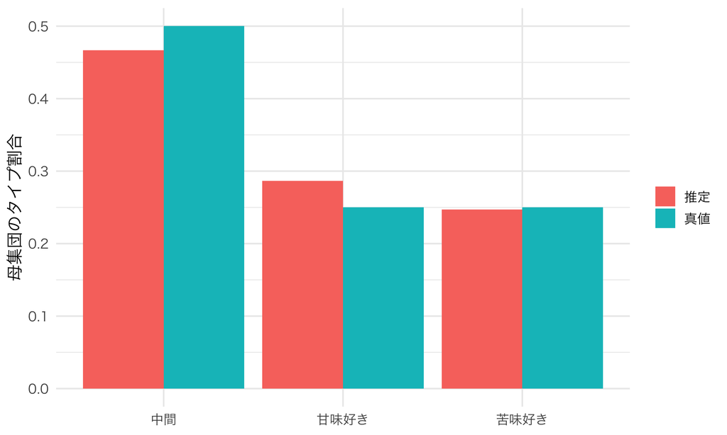

母集団のタイプ割合。真のタイプは生成時にのみ使い、推定には渡さない。

```r
pi_plot <- rbind(data.frame(type = type_names, value = pi_true, method = "真値"),
                 data.frame(type = type_names, value = pi_hat, method = "推定"))
ggplot(pi_plot, aes(type, value, fill = method)) + geom_col(position = "dodge") +
  labs(x = NULL, y = "母集団のタイプ割合", fill = NULL)
```

これは経験ベイズである。以降は推定した $\widehat\pi$ を固定して使う。個人のタイプの不確実性は $w_{ik}$ に残るが、母集団割合の推定誤差まで全て反映した分布ではない。

### 1.3 選択確率を事後分布で平均する

次回の価格・属性を指定したとき、顧客 $i$ の予測選択確率は

$$\widehat P_{ij}=\sum_{k=1}^3w_{ik}P_j(\vartheta_k;p,x)$$

である。各タイプならどのくらい選ぶかを計算し、「そのタイプらしさ」で平均する。履歴がなければ $w_{ik}=\widehat\pi_k$ とすればよい。

例えば両商品が300円で、6回の選択が次のように観測された人を比べよう。0は「買わない」である。

```r
example_y <- list("Aを6回" = rep(1, 6), "A・B・非購入" = c(1, 2, 0, 0, 1, 2),
                  "Bを6回" = rep(2, 6), "非購入を6回" = rep(0, 6))
example_data <- do.call(rbind, lapply(seq_along(example_y), function(i) {
  data.frame(id = i, t = 1:6, pA = 3, pB = 3, xA = -1, xB = 1, y = example_y[[i]])
}))
w_example <- posterior_weights(history_loglik(example_data), pi_hat)
p0_type <- choice_prob(theta_grid, 3, 3)
pred_example <- w_example %*% p0_type
example_table <- data.frame(history = names(example_y), w_example, pred_example)
knitr::kable(example_table, digits = 3,
  col.names = c("履歴", "苦味好きの確率", "中間の確率", "甘味好きの確率",
                "次回非購入", "次回A", "次回B"))
```

| 履歴 | 苦味好きの確率 | 中間の確率 | 甘味好きの確率 | 次回非購入 | 次回A | 次回B |
| --- | --- | --- | --- | --- | --- | --- |
| Aを6回 | 0.998 | 0.002 | 0.000 | 0.488 | 0.487 | 0.025 |
| A・B・非購入 | 0.057 | 0.876 | 0.066 | 0.666 | 0.165 | 0.169 |
| Bを6回 | 0.000 | 0.002 | 0.998 | 0.488 | 0.025 | 0.487 |
| 非購入を6回 | 0.057 | 0.876 | 0.066 | 0.666 | 0.165 | 0.169 |

ここで、$\widehat\theta_i=\sum_kw_{ik}\vartheta_k$ を一度だけlogitに代入する計算とは区別したい。一般に

$$\sum_kw_{ik}P_j(\vartheta_k)\ne P_j\!\left(\sum_kw_{ik}\vartheta_k\right).$$

「苦味好きか甘味好きか分からない」人と「中間タイプらしい」人は、タイプの平均が同じ0でも、予測される購入行動が違う。非線形な確率を計算する前に、好みを一つの平均値へつぶさないことが重要である。

**ノートビジネスの現場で：顧客データに何を残すか**

「何を買ったか」に加えて、そのときの選択肢と価格が必要になる。Aしか在庫がない日にAを買ったことと、A・Bの両方からAを選んだことは同じ情報ではない。「買わない」を扱うなら、購入機会の定義と非購入の記録も必要だ。本人の履歴を詳しく集めても、提示条件が分からなければ好みと環境の影響を分けにくい。

## 2. ターゲティング：好みの推測を、クーポンの配布に使う

### 2.1 買いそうな人と、配ると利益が増える人

次の一回の機会について、Aの50円引きクーポンを配るかを決める。通常価格はA・Bとも300円、原価はAが50円、Bが100円、配布費は購入しなくても2円とする。A・Bはどちらも自社商品である。

| 施策 $a$ | Aの価格 | Bの価格 | Aの粗利 | Bの粗利 | 配布費 |
| --- | --- | --- | --- | --- | --- |
| 非配布 0 | 300円 | 300円 | 250円 | 200円 | 0円 |
| Aクーポン 1 | 250円 | 300円 | 200円 | 200円 | 2円 |

価格の変化は、買わなかった人の購入を増やすかもしれない。一方、もともとAを買う人への値引きや、BからAへの乗り換えも起こる。Aの購入確率の上昇だけで採否を決めず、**自社のA・Bを合わせた利益**を比較する。

タイプ $k$ のもとでの施策 $a$ の期待利益を

$$r_k(a)=\sum_{j=A,B}100\{p_j(a)-c_j\}P_j(\vartheta_k;p(a),x)-2a$$

とする。$c_A=0.5,c_B=1$ は100円単位の原価で、式全体は円になる。クーポンはその一回の価格だけを変え、注意を引く効果、好みの変化、将来への持越しはないと仮定する。

```r
cost <- c(.5, 1)
p1_type <- choice_prob(theta_grid, 2.5, 3)
r0_type <- drop(p0_type[, 2:3] %*% (100 * (c(3, 3) - cost)))
r1_type <- drop(p1_type[, 2:3] %*% (100 * (c(2.5, 3) - cost))) - 2
gain_type <- r1_type - r0_type
type_profit <- data.frame(type = type_names, base = r0_type,
                          coupon = r1_type, gain = gain_type)
knitr::kable(type_profit, digits = 2,
  col.names = c("タイプ", "非配布の期待利益", "配布の期待利益", "増分（円）"))
```

| タイプ | 非配布の期待利益 | 配布の期待利益 | 増分（円） |
| --- | --- | --- | --- |
| 苦味好き | 126.82 | 123.88 | -2.94 |
| 中間 | 69.43 | 72.29 | 2.87 |
| 甘味好き | 103.64 | 101.94 | -1.70 |

苦味好きは非配布でもAを選びやすいため、値引きで失う利益が大きい。中間タイプは、この価格と費用ではクーポンによる増分が正になる。甘味好きにAの値引きをしても反応は小さい。**価格感応度 $\alpha$ が全員同じでも、出発点の選択確率が違えば施策への反応は異なる。** これは今回の設定での結果であり、費用や価格を変えれば配るべき相手も変わる。

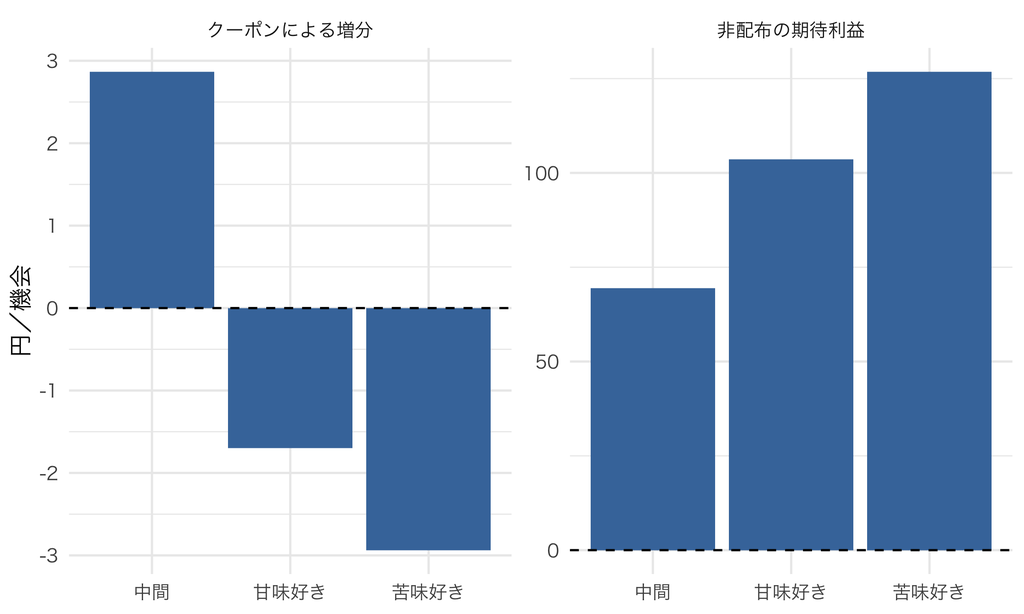

タイプ別の非配布利益とクーポン増分。縦軸の尺度はパネルごとに異なる。

```r
type_profit_plot <- rbind(
  data.frame(type = type_names, measure = "非配布の期待利益", value = r0_type),
  data.frame(type = type_names, measure = "クーポンによる増分", value = gain_type))
ggplot(type_profit_plot, aes(type, value)) + geom_col(fill = "#4477aa") +
  geom_hline(yintercept = 0, linetype = 2) +
  facet_wrap(~measure, scales = "free_y") + labs(x = NULL, y = "円／機会")
```

### 2.2 タイプを知らなくても、利益を平均できる

実際の顧客についてはタイプを知らない。そこで、前節で求めた $w_{ik}$ をそのまま使う。

$$\widehat R_i(a)=\sum_kw_{ik}r_k(a),
\qquad
\widehat\Delta_i=\sum_kw_{ik}\{r_k(1)-r_k(0)\}.$$

予算制約や他人への影響がなければ、$\widehat\Delta_i>0$ の人に配る。一番確率が高いタイプを選んで決める必要はない。配布・非配布の両方で、**施策前の同じ重み**を使う。クーポン後の購入でタイプを更新してから、過去の配布を正当化してはいけない。

```r
base_profit <- drop(w %*% r0_type)
gain <- drop(w %*% gain_type)
decision <- as.integer(gain > 0)
target_examples <- data.frame(history = names(example_y),
  base = drop(w_example %*% r0_type), gain = drop(w_example %*% gain_type))
target_examples$send <- target_examples$gain > 0
knitr::kable(target_examples, digits = 2,
  col.names = c("履歴", "非配布の予測利益", "クーポンの予測増分", "配布する"))
```

| 履歴 | 非配布の予測利益 | クーポンの予測増分 | 配布する |
| --- | --- | --- | --- |
| Aを6回 | 126.71 | -2.93 | FALSE |
| A・B・非購入 | 74.98 | 2.23 | TRUE |
| Bを6回 | 103.59 | -1.69 | FALSE |
| 非購入を6回 | 74.98 | 2.23 | TRUE |

この計算が施策の効果を表すには、価格への反応を表すモデルが変更後にも成り立つ必要がある。今回は価格係数を既知としており、価格も無作為化したシミュレーションなので、その仮定を置ける。現実には、価格内生性を解決して係数を推定し、クーポンが実質価格以外にも効くかを確かめる必要がある。**タイプを詳しく推測できることだけで、施策の因果効果が分かるわけではない。**

**ヒント研究コラム：Rossi・McCulloch・Allenby — 購買履歴にはいくらの価値があるか**

[Rossi, McCulloch and Allenby (1996)](https://pubsonline.informs.org/doi/abs/10.1287/mksc.15.4.321) は、世帯の購買履歴や属性からrandom coefficient選択モデルを推定し、個別のクーポンを設計した。どの情報を使えるかを変え、ターゲティングによる純収入の増分を比較する。短い購買履歴を使った場合でも、一律配布による増分の約2.5倍となる結果を報告した。これはモデルに基づく当該データでの評価であり、どの企業にも同じ倍率を保証する実験結果ではない。本講義の「履歴からタイプの分布を学び、それを利益の比較に使う」という流れに直接対応する。

### 2.3 固定した配布ルールを、別の実験で評価する

予測から作ったルールが実際に利益を増やすか、独立した将来の購買機会で確認する。6000人の施策前履歴から上のルールを固定した後、確率 $e=1/2$ でクーポンを無作為に配る。実験の配布 $D_i$ と、採用を検討するルール $d(H_i)$ は別物である。

観測利益は、選択が $Y_i$ なら

$$R_i=100\{p_A(D_i)-c_A\}\mathbf1\{Y_i=A\}
+100(p_B-c_B)\mathbf1\{Y_i=B\}-2D_i$$

となる。計量Iの潜在アウトカムでいえば、同じ人の $R_i(1)$ と $R_i(0)$ の片方しか観測していない。無作為割付を使うと、ルール $d$ の一律非配布に対する平均増分を

$$\widehat G(d)=\frac1n\sum_i Z_i(d),\qquad
Z_i(d)=d(H_i)\left\{\frac{D_iR_i}{e}
-\frac{(1-D_i)R_i}{1-e}\right\}$$

で推定できる。これが逆確率重み付け（IPW）である。標準誤差には $\operatorname{sd}(Z_i(d))/\sqrt n$ を使う。利益の単位は配布された人一人当たりではなく、**対象顧客全員一人当たり**だ。

```r
set.seed(20260703)
n_customer <- nrow(w)
D <- rbinom(n_customer, 1, .5)
p_exp <- choice_prob(theta_grid[customers$type], 3 - .5 * D, 3)
y_exp <- draw_choice(p_exp)
R <- (250 - 50 * D) * (y_exp == 1) + 200 * (y_exp == 2) - 2 * D
# 高価値顧客への配布は、比較のため人数をモデルのルールにそろえる
n_send <- sum(decision)
high_value <- integer(n_customer)
high_value[head(order(-base_profit), n_send)] <- 1
rules <- list("非配布" = rep(0, n_customer), "全員" = rep(1, n_customer),
              "高価値から同人数" = high_value, "増分が正" = decision)
policy_table <- do.call(rbind, lapply(names(rules), function(nm) {
  rule <- rules[[nm]]
  z <- rule * (D * R / .5 - (1 - D) * R / .5)
  data.frame(rule = nm, send_rate = mean(rule), estimate = mean(z),
    se = sd(z) / sqrt(n_customer),
    truth = mean(rule * gain_type[customers$type]))
}))
knitr::kable(policy_table, digits = 3,
  col.names = c("ルール", "配布割合", "実験での増分推定（円）", "標準誤差",
                "評価顧客での真の期待増分"))
```

| ルール | 配布割合 | 実験での増分推定（円） | 標準誤差 | 評価顧客での真の期待増分 |
| --- | --- | --- | --- | --- |
| 非配布 | 0.000 | 0.000 | 0.000 | 0.000 |
| 全員 | 1.000 | -0.087 | 3.634 | 0.288 |
| 高価値から同人数 | 0.548 | 2.582 | 2.853 | -0.574 |
| 増分が正 | 0.548 | -0.889 | 2.506 | 0.918 |

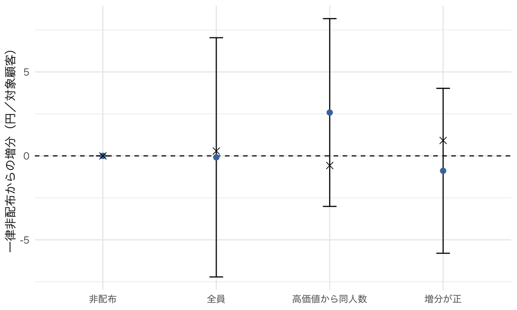

固定したルールの実験評価と近似95%信頼区間。×は生成モデルからの比較基準。

```r
policy_table$rule <- factor(policy_table$rule, levels = names(rules))
ggplot(policy_table, aes(rule, estimate)) +
  geom_hline(yintercept = 0, linetype = 2) +
  geom_errorbar(aes(ymin = estimate - 1.96 * se, ymax = estimate + 1.96 * se), width = .12) +
  geom_point(size = 2.5, color = "#4477aa") +
  geom_point(aes(y = truth), shape = 4, size = 3) +
  labs(x = NULL, y = "一律非配布からの増分（円／対象顧客）")
```

真のタイプは、データ生成と最後の答え合わせだけに使った。配布ルールは、観測された過去の選択と学習用標本の推定結果だけから作っている。

モデル上の増分が正でも、一回の実験では信頼区間が0をまたぐことがある。今回のように一人当たり数円の差を、一回の購入から得る数百円のばらつきの中で測るのは難しい。表の点推定だけで有効性を断定しない。ここでの区間は固定したルールの評価についてであり、学習標本を取り直したときのルールの変動やモデルの誤りは含まない。

**ノートビジネスの現場で：実験と選択モデルの役割**

決まったクーポンを配るかだけなら、実験から履歴別の利益差を直接学ぶ方法もある。選択モデルは、タイプの不確実性や商品間の代替をまとめて扱い、価格・商品構成を変えた比較にも使える。その分、価格反応や効用の形に仮定を置く。モデルで施策を提案し、ランダム化実験でそのルールの利益を検証する、という使い分けができる。

**ヒント研究コラム：Ascarza — 離脱リスクと、引き止める効果**

[Ascarza (2018)](https://www.hbs.edu/ris/Publication%20Files/ascarza_jmr_18_783d54d4-e548-41ed-b1d7-8a180f1ae85a.pdf) は、通信と会員制サービスの2つのフィールド実験から、施策への反応の違いを調べた。離脱リスクの高い人と、介入で離脱を防げる人を区別し、同じ施策の配布先を比較する。反応に基づく配分では、離脱リスクに基づく配分より離脱率をさらに4.1ポイント、8.7ポイント下げられると試算した。これは各市場での結果であり、普遍的な改善幅ではない。好み・リスク・利益の水準と、介入による増分を区別する理由が分かる。

## 3. 顧客価値：同じ選択モデルで、将来利益を足し合わせる

### 3.1 今後半年の期待利益を知りたい

次は同じ顧客について、クーポンを配らず、今後6か月にどれだけ利益を生むかを考える。新しい購買回数モデルへ切り替える必要はない。前節の非配布時の選択確率と粗利を、将来の各機会について計算すればよい。

顧客生涯価値（customer lifetime value、CLV）は、顧客が将来もたらす利益の割引期待値である。ここでは無限の将来まで含めず、今後 $H$ か月の粗利益に区切った有限期間の顧客価値を使う。月ごとの割引係数を $\delta$ とすれば、

$$V_i(H)=E\!\left[\left.\sum_{h=1}^H\delta^h M_{ih}\right|H_i\right],
\qquad
\widehat V_i(H)=\sum_{h=1}^H\delta^h
\sum_kw_{ik}\sum_{j=A,B}m_{jh}P_j(\vartheta_k;p_h,x_h).$$

$m_{jh}$ は円単位の粗利である。$H$ は予測する月数、$H_i$ はこれまでの履歴を表す。**履歴からタイプを学び、タイプごとの選択確率を平均し、粗利を掛けて将来へ足す。** CLVはこの計算で求める目的量であり、特定の統計モデルの名前ではない。

今回は月に一回の選択機会があり、毎月A・B・非購入から一つ選ぶ。価格は300円ずつ、原価も一定で、タイプの変化・離脱・買いだめはない。分析時点の履歴で条件づけ、途中で得る将来のデータによる施策変更も行わない。この場合、

$$\widehat V_i(6)=\left(\sum_{h=1}^6 0.99^h\right)\widehat R_i(0).$$

1か月先の100円を現在の99円と評価する設定である。CLVには獲得費や新しい施策費を自動的には含めない。

```r
horizon <- 6
discount <- .99
clv_factor <- sum(discount ^ seq_len(horizon))
clv_pred <- clv_factor * base_profit
clv_example <- data.frame(history = names(example_y),
  monthly = drop(w_example %*% r0_type),
  value = clv_factor * drop(w_example %*% r0_type))
knitr::kable(clv_example, digits = 1,
  col.names = c("履歴", "1か月の期待粗利益（円）", "6か月の顧客価値（円）"))
```

| 履歴 | 1か月の期待粗利益（円） | 6か月の顧客価値（円） |
| --- | --- | --- |
| Aを6回 | 126.7 | 734.1 |
| A・B・非購入 | 75.0 | 434.4 |
| Bを6回 | 103.6 | 600.1 |
| 非購入を6回 | 75.0 | 434.4 |

### 3.2 未来の選択を生成し、予測を検証する

施策前の履歴から作った予測を固定し、クーポンの評価実験とは別の6か月の選択を生成する。同じ顧客の真のタイプを固定したまま、毎月新しい選択ショックを引く。分析者には将来の選択も真のタイプも見せない。

```r
set.seed(20260704)
future_prob <- choice_prob(theta_grid[customers$type], 3, 3)
future_y <- sapply(seq_len(horizon), function(h) draw_choice(future_prob))
future_margin <- 250 * (future_y == 1) + 200 * (future_y == 2)
clv_observed <- drop(future_margin %*% (discount ^ seq_len(horizon)))
# 過去だけから予測したCLVで5群に分ける。同順位は顧客ID順。
clv_group <- pmin(5, ceiling(5 * rank(clv_pred, ties.method = "first") / n_customer))
clv_table <- do.call(rbind, lapply(1:5, function(g) {
  ix <- clv_group == g
  data.frame(group = g, n = sum(ix), predicted = mean(clv_pred[ix]),
    observed = mean(clv_observed[ix]),
    truth = mean(clv_factor * r0_type[customers$type[ix]]))
}))
knitr::kable(clv_table, digits = 1,
  col.names = c("予測CLVの低い順", "人数", "予測（円）", "6か月の実績（円）",
                "真のタイプからの期待値（円）"))
```

| 予測CLVの低い順 | 人数 | 予測（円） | 6か月の実績（円） | 真のタイプからの期待値（円） |
| --- | --- | --- | --- | --- |
| 1 | 1200 | 437.2 | 444.6 | 435.3 |
| 2 | 1200 | 464.5 | 458.5 | 457.7 |
| 3 | 1200 | 521.8 | 519.8 | 511.8 |
| 4 | 1200 | 585.6 | 579.9 | 581.6 |
| 5 | 1200 | 689.2 | 697.2 | 685.4 |

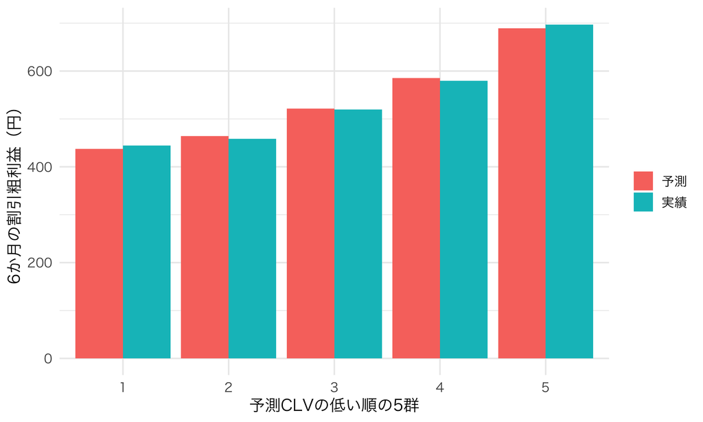

施策前の予測で作った5群のCLV。グループ平均の一致と個人の予測精度は別である。

```r
clv_plot <- rbind(
  data.frame(group = clv_table$group, value = clv_table$predicted, method = "予測"),
  data.frame(group = clv_table$group, value = clv_table$observed, method = "実績"))
ggplot(clv_plot, aes(factor(group), value, fill = method)) +
  geom_col(position = "dodge") +
  labs(x = "予測CLVの低い順の5群", y = "6か月の割引粗利益（円）", fill = NULL)
```

履歴を使わず、全員に母集団平均のCLVを当てる方法とも比較しよう。以下は個人ごとの実現利益との二乗誤差の平均である。

```r
clv_pooled <- clv_factor * sum(pi_hat * r0_type)
clv_error <- data.frame(method = c("母集団の割合だけ", "本人の履歴も使う"),
  mse = c(mean((clv_pooled - clv_observed)^2),
          mean((clv_pred - clv_observed)^2)))
knitr::kable(clv_error, digits = 1,
  col.names = c("予測方法", "将来実績との平均二乗誤差（円²）"))
```

| 予測方法 | 将来実績との平均二乗誤差（円²） |
| --- | --- |
| 母集団の割合だけ | 86031.2 |
| 本人の履歴も使う | 77170.2 |

個人の実現利益には、タイプの不確実性に加えて、未来の選択ショックによる偶然がある。タイプが完全に分かっても実現利益を完全には予測できない。また今回は生成と推定に同じモデルを使った確認である。実データでは別期間での検証を行い、来店機会数や季節性、離脱が変わっていないかを見る必要がある。

### 3.3 高い顧客価値と、施策で増やせる顧客価値

今の設定では、6か月CLVの順位は非配布の1回当たり利益の順位と同じになる。しかしクーポンの配布には、その水準ではなく差が必要だった。長期施策でも同じで、施策 $a$ が作る将来の価格・選択確率・費用を使って $V_i(H;a)$ を求め、

$$\Delta_i^{\mathrm{CLV}}=
V_i(H;1)-V_i(H;0)-\text{別途必要な施策費}$$

を比較する。$V$ の中で既に差し引いた費用は、もう一度差し引かない。

今回の一回限りのクーポンには、好みや将来の選択を変える仕組みがない。そのため、初月に配るなら長期の利益差も初月の差の割引値だけになる。毎月配る場合でも、先読みや持越しがないという仮定の範囲で、各月の差を合計する。現在の購入が後の習慣や在庫を変えるなら、このモデルの外にある仕組みを追加しなければならない。

**ノート補足：購買頻度・離脱を直接モデル化する方法もある**

購買回数をPoisson–Gammaで予測し、固定した一回当たり粗利を掛ける方法や、BG/NBDで購買頻度と離脱を扱う方法も、CLVを求める別の方法である。現状の将来購買を予測する目的では有用だが、基本形には商品の効用比較や価格変更への反応が入っていない。本講義では、第6回の個人の好みの推定を、商品別の選択確率と利益につなぐため、離散選択モデルを使った。[Fader, Hardie and Lee (2005)](https://faculty.wharton.upenn.edu/wp-content/uploads/2012/06/BGNBD_FHL_MktgSci_2005_1.pdf) は購買頻度と離脱に絞ったモデルの例である。

## 4. コンジョイント：好みを学ぶための選択履歴を作る

### 4.1 今ある商品の履歴だけで、商品設計まで分かるか

今度はAの甘さと価格を変えたい。これまではAが苦く、Bが甘いという組合せが固定されていた。このモデルでは甘さ係数を通じて新しい組合せも計算できるが、実際のデータではブランドや他の品質と甘さが結びついており、その区別が難しいことがある。

そこで、商品の属性と価格を組み替えた質問を提示し、どれを選ぶかを尋ねる。これが**選択型コンジョイント（choice-based conjoint、CBC）**である。今回の選択肢は、商品案A、商品案B、「どちらも買わない」とする。A・Bは質問内のラベルであり、特定のブランド名の効用は置かない。

| 調査で変えるもの | 提示する値 |
| --- | --- |
| A・Bそれぞれの甘さ $x$ | 苦い $-1$、中間 $0$、甘い $1$ |
| A・Bそれぞれの価格 $p$ | 250円、300円、350円 |
| 各回答者の課題数 | 8問。最初の6問で学び、後の2問で予測を確認 |

各属性を独立に無作為化する。例えば価格を同じにして甘さを変えたり、同じ甘さで価格を変えたりできるようになる。一人の回答を追えるIDも残す。

**コンジョイントは、これまでと別の選択理論ではない。選択モデルに与えるデータの集め方である。** 毎回の提示条件と選択結果があれば、第6回と同じようにその人のタイプを更新できる。

### 4.2 同じ人の回答を掛け合わせて、タイプを学ぶ

調査でも

$$u_{ijt}=1.5+\theta_i x_{jt}-p_{jt}+\varepsilon_{ijt}$$

を使う。タイプの位置、価格係数、効用の尺度を既知とする簡略化はここでも同じだ。実務では共通係数やタイプの位置も推定するが、今回は回答履歴による更新と、その後の意思決定に集中する。

新しく600人の調査回答者を生成する。前節の顧客とは別の人なので、個人別の重みを流用しない。母集団割合もこの調査の最初の6問から推定し直す。生成時の割合は比較のため同じ値に置く。

```r
survey <- simulate_history(600, 8, 20260705, conjoint = TRUE)
survey_train <- subset(survey$data, t <= 6)
survey_test <- subset(survey$data, t > 6)
survey_loglik <- history_loglik(survey_train)
pi_cj <- estimate_pi(survey_loglik)
w_cj <- posterior_weights(survey_loglik, pi_cj)
survey_pi_table <- data.frame(type = type_names, truth = pi_true, estimate = pi_cj)
knitr::kable(survey_pi_table, digits = 3,
  col.names = c("タイプ", "生成時の割合", "調査の最初の6問からの推定"))
```

| タイプ | 生成時の割合 | 調査の最初の6問からの推定 |
| --- | --- | --- |
| 苦味好き | 0.25 | 0.224 |
| 中間 | 0.50 | 0.528 |
| 甘味好き | 0.25 | 0.248 |

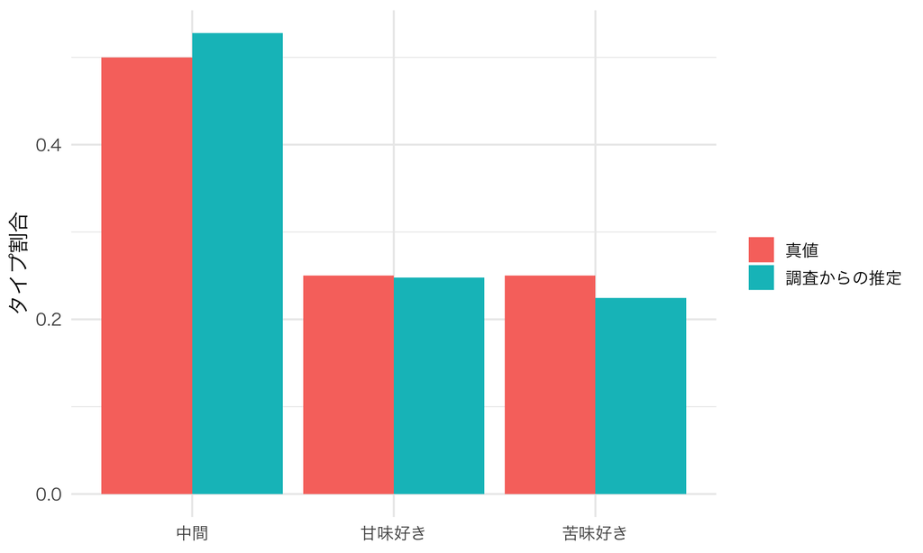

コンジョイント回答から推定した母集団のタイプ割合。

```r
survey_pi_plot <- rbind(
  data.frame(type = type_names, value = pi_true, method = "真値"),
  data.frame(type = type_names, value = pi_cj, method = "調査からの推定"))
ggplot(survey_pi_plot, aes(type, value, fill = method)) +
  geom_col(position = "dodge") + labs(x = NULL, y = "タイプ割合", fill = NULL)
```

数式で書けば、各人の調査回答の尤度は

$$L_i^C(\vartheta_k)=\prod_{t=1}^{6}
P_{y_{it}^C}(\vartheta_k;p_t^C,x_t^C),
\qquad
w_{ik}^C=\frac{\widehat\pi_k^C L_i^C(\vartheta_k)}
{\sum_\ell\widehat\pi_\ell^C L_i^C(\vartheta_\ell)}.$$

調査回答を本人の履歴として使うだけなので、計算は第1節と同じである。母集団全体が分かっても各人のタイプが確定するわけではなく、6問答えても重みは分布として残る。

後の2問は、母集団割合や本人の重みの更新に使わず、予測を確かめる。全員に同じ母集団割合を使う予測と、本人の最初の6問も使う予測を比較する。

```r
predict_choices <- function(dat, weights) {
  ans <- matrix(0, nrow(dat), 3)
  for (k in 1:3) {
    pr <- with(dat, choice_prob(theta_grid[k], pA, pB, xA, xB))
    ans <- ans + pr * weights[dat$id, k]
  }
  ans
}
p_cj_person <- predict_choices(survey_test, w_cj)
p_cj_population <- predict_choices(survey_test,
  matrix(rep(pi_cj, each = nrow(w_cj)), ncol = 3))
pick_cj <- cbind(seq_len(nrow(survey_test)), survey_test$y + 1)
survey_validation <- data.frame(method = c("母集団の割合だけ", "本人の6回答も使う"),
  logloss = c(-mean(log(p_cj_population[pick_cj])),
              -mean(log(p_cj_person[pick_cj]))))
knitr::kable(survey_validation, digits = 3,
  col.names = c("予測方法", "後の2問の対数損失（小さいほどよい）"))
```

| 予測方法 | 後の2問の対数損失（小さいほどよい） |
| --- | --- |
| 母集団の割合だけ | 0.849 |
| 本人の6回答も使う | 0.817 |

対数損失は、実際に選ばれた選択肢にどれだけ高い確率を付けたかを見る指標である。この比較は調査内の予測を確認している。現実の売上への予測精度まで確かめたわけではない。

### 4.3 好みの分布から、候補商品の利益へ

Aの甘さ3通りと価格3通りを組み合わせた9候補を比較する。既存のBは甘さ1・300円に固定し、両方とも自社商品とする。Aの原価は甘さによらず50円、Bは100円と仮定する。甘さによって製造費が違うなら、その費用も変える必要がある。

候補 $a=(x_A,p_A)$ の、回答者 $i$ についての期待粗利益は

$$\widehat R_i(a)=
\sum_kw_{ik}^C
\left[100(p_A-0.5)P_A(\vartheta_k;a,B)
+200P_B(\vartheta_k;a,B)\right].$$

クーポンを配る計算と同じく、候補のもとで選択確率を求め、利益をタイプ分布で平均する。Aだけの売上を最大にすると、Bから移ってきた購入を全て純増と数える恐れがある。比較の基準は、従来のA（苦い・300円）とBを合わせた期待粗利益である。

```r
candidates <- expand.grid(xA = -1:1, pA = c(2.5, 3, 3.5))
candidate_type_profit <- sapply(seq_len(nrow(candidates)), function(a) {
  pr <- choice_prob(theta_grid, candidates$pA[a], 3, candidates$xA[a], 1)
  drop(pr[, 2:3] %*% c(100 * (candidates$pA[a] - .5), 200))
})
candidate_person_profit <- w_cj %*% candidate_type_profit
baseline_cj <- drop(w_cj %*% r0_type)
candidates$profit <- colMeans(candidate_person_profit)
candidates$gain <- colMeans(candidate_person_profit - baseline_cj)
candidates$true_profit <- colMeans(candidate_type_profit[survey$type, , drop = FALSE])
candidate_table <- candidates[order(-candidates$profit), ]
knitr::kable(candidate_table, digits = 2, row.names = FALSE,
  col.names = c("Aの甘さ", "Aの価格（100円）", "A+Bの期待粗利益（円）",
                "現行商品からの増分（円）", "真のタイプでの期待粗利益（円）"))
```

| Aの甘さ | Aの価格（100円） | A+Bの期待粗利益（円） | 現行商品からの増分（円） | 真のタイプでの期待粗利益（円） |
| --- | --- | --- | --- | --- |
| -1 | 2.5 | 93.22 | 2.43 | 93.75 |
| -1 | 3.0 | 90.79 | 0.00 | 91.36 |
| -1 | 3.5 | 84.64 | -6.15 | 85.01 |
| 0 | 2.5 | 81.07 | -9.72 | 80.01 |
| 1 | 2.5 | 80.43 | -10.36 | 78.11 |
| 1 | 3.0 | 78.40 | -12.39 | 75.94 |
| 0 | 3.0 | 76.75 | -14.04 | 75.56 |
| 1 | 3.5 | 73.39 | -17.40 | 70.96 |
| 0 | 3.5 | 70.62 | -20.17 | 69.30 |

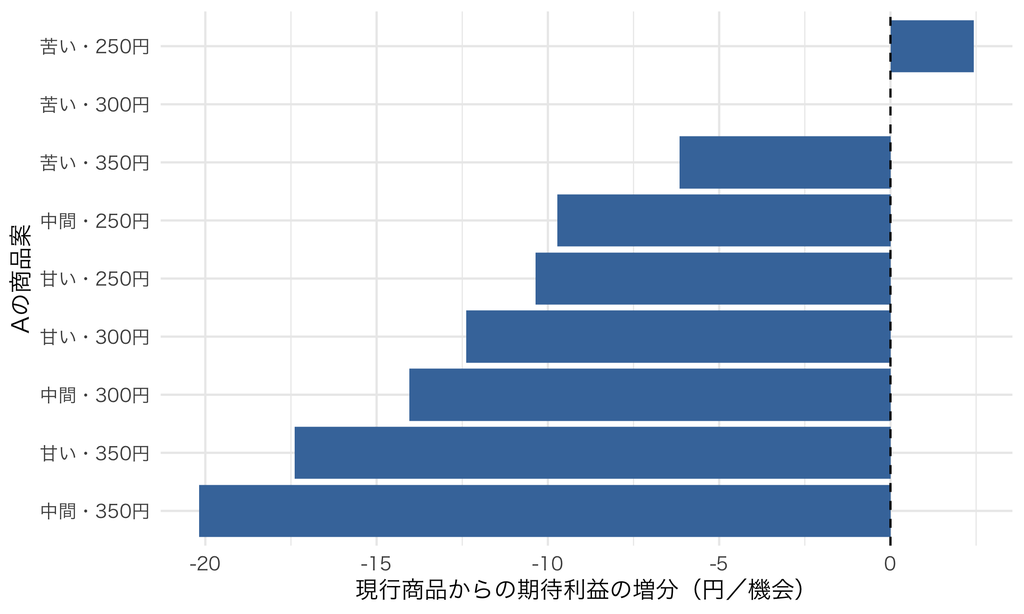

Aの9候補を、自社A・Bの合計利益で比較する。基準は苦いA・300円。

```r
candidates$name <- paste0(c("苦い", "中間", "甘い")[candidates$xA + 2],
                           "・", 100 * candidates$pA, "円")
ggplot(candidates, aes(reorder(name, gain), gain)) +
  geom_col(fill = "#4477aa") + geom_hline(yintercept = 0, linetype = 2) +
  coord_flip() + labs(x = "Aの商品案", y = "現行商品からの期待利益の増分（円／機会）")
```

全顧客に同じ商品を売るなら、顧客についても平均した利益が最大の候補を選ぶ。顧客ごとに推薦を変えられるなら、個人別の $\widehat R_i(a)$ を比較する。ただし推薦が選択肢や注意をどう変えるかは、別途モデル化する必要がある。

ここで、同じ調査標本について $w_{ik}^C$ を平均すると、EMの収束時には $\widehat\pi_k^C$ と一致する。したがって全回答者向けの一つの商品の選択には、母集団割合だけでも同じ平均利益を計算できる。**個人の重みが特に必要なのは、個人別の判断や、特定の顧客群についての比較をするときである。**

```r
stopifnot(max(abs(colMeans(w_cj) - pi_cj)) < 1e-8)
stopifnot(max(abs(colMeans(candidate_person_profit) -
                    drop(pi_cj %*% candidate_type_profit))) < 1e-6)
```

現実の新規顧客へ売る場合、調査回答者の平均が対象市場の平均を表すかも確認する。今回の表はモデルと9候補のもとでの比較であり、開発費、他社の反応、調査にない属性まで含めた最適商品を保証しない。

### 4.4 調査から新しく分かること、追加で必要なこと

ここでは、これまでと同じ甘さの軸について質問を設計した。産地表示という新しい属性を追加するなら、効用にも例えば $\gamma_i\,\text{産地表示}_{jt}$ を加え、その係数の分布を学べる質問が必要になる。**甘さの好みを詳しく推定できても、産地表示への好みが自動的に分かるわけではない。**

同じ会員について購買履歴と調査回答を合わせるなら、同一人物であることに加え、両方を同じタイプで説明できるという仮定が必要になる。共通の効用尺度と、タイプで条件づけた独立性まで置ける場合には、

$$w_{ik}^{H,C}\ \propto\
\pi_k L_i^H(\vartheta_k)L_i^C(\vartheta_k)$$

と更新できる。調査では気軽に高い商品を選び、実店舗では支払額を気にするかもしれない。そのときは、回答を機械的に掛け合わせず、調査と実購買の違いをモデルに入れ、実販売で確かめる。

**ノート補足：AMCE・WTP・期待利益は、同じ量ではない**

AMCE（平均限界構成要素効果）は、他の属性や対抗商品を調査の割付分布で平均したとき、ある属性の変更が選択確率を何ポイント変えるかを表す。無作為化した属性の比較から学べるが、個人のタイプや効用係数そのものではない。同じ人が何問も答えるときの標準誤差は、回答者単位で扱う。

一方、この線形効用で甘さを1単位増やすWTPは、タイプ $k$ なら $100\vartheta_k/\alpha$ 円である。苦味好きでは負になる。属性の好ましさを金額に換算する量であって、企業の利益ではない。商品設計には、価格・原価・他商品からの乗り換えも含めた期待利益を使う。AMCEは調査設計の分布に依存し、WTPは効用の形や価格係数に依存する。

**ヒント研究コラム：調査の選択と、現実の行動は同じか**

[Hainmueller, Hangartner and Yamamoto (2015)](https://pmc.ncbi.nlm.nih.gov/articles/PMC4345583/) は、スイスの帰化申請について、仮想的な選択調査と実際の住民投票を比較した。対応する属性を使うことで、調査内で測った属性の効果が実際の行動にも近いかを検証する。2人を並べるコンジョイントでは、属性効果は実際の行動の基準に平均しておおむね2ポイント以内まで近かった。一方、調査から計算した棄却率は約21%、実際は約37%だった。属性間の比較が近くても、行動の水準まで一致するとは限らない。コーヒーの調査でも、タイプの推定に加えて、実際に支払う状況へ予測を移せるかを確認する必要がある。

## 5. 個人の好みの推定を、何に使ったか

第6回の到達点は、本人のタイプについての分布だった。今回、その重みを使って三つの判断を行った。

| 場面 | タイプの分布をどう使うか | 判断・確認すること |
| --- | --- | --- |
| ターゲティング | 施策あり・なしの利益差を平均する | 増分が正の人に配る。固定したルールを実験で評価 |
| 顧客価値 | 将来の商品選択確率を平均し、粗利と割引係数を掛けて合計する | 所定の環境での将来価値と、施策で増える価値を区別 |
| コンジョイント | 設計した選択質問からタイプ分布を更新し、候補商品の利益を平均する | 属性と価格を比較できる調査、対象市場での予測の妥当性 |

**重要今回のまとめ**

- 個人の選択確率は、タイプごとの確率を事後確率で平均して求める。
- 施策の配分には、同じ履歴で条件づけた施策あり・なしの利益差を使う。
- CLVは、同じ選択モデルが予測する将来利益の割引合計として計算できる。
- コンジョイントは、好みを学ぶために属性と価格を変えた選択履歴を作る方法である。
- 個人別の判断には本人の重み、全市場向けの商品比較には対象市場のタイプ分布が必要になる。
- モデルによる比較、独立データでの予測、実験による施策評価を区別して確かめる。

### 宿題

1. 苦味好きである確率が高い人に、Aのクーポンを送ると利益が減る理由を、値引き前の購入と粗利から説明しよう。
2. 同じ人のタイプの事後平均をlogitに代入する方法と、タイプ別の選択確率を平均する方法を比べよう。
3. 月に一回から二回の選択機会へ変えると、今回の仮定のもとでCLVはどう変わるか。どの仮定が崩れると単純に2倍できないか。
4. 産地表示への好みを学ぶコンジョイントを作るなら、モデルと質問のどこを追加するか考えよう。

coding課題は課題7（編集用：assignment7.qmd）を参照する。ブラウザ実験室では、本人の履歴・費用・商品案を変えて、同じタイプの重みが判断にどう効くかを確かめられる。

### この先の講義とのつながり

第8回は企業でのエコノミストの仕事を扱うゲスト講義である。第9回では、消費者自身が将来を考える動学的離散選択へ進む。今回も将来利益を割り引いたが、消費者は毎回その機会の効用だけを比べた。「来月の値下げを待つ」「今まとめ買いして次の購入を減らす」という選択は入っていない。分析者が将来を予測することと、消費者が将来を考えて今の選択を変えることを区別しよう。

講義一覧へ

### 参考文献

- Rossi, P. E., R. E. McCulloch, and G. M. Allenby (1996). “The Value of Purchase History Data in Target Marketing.” *Marketing Science*, 15(4), 321–340. [原論文](https://doi.org/10.1287/mksc.15.4.321)
- Ascarza, E. (2018). “Retention Futility: Targeting High-Risk Customers Might Be Ineffective.” *Journal of Marketing Research*, 55(1), 80–98. [著者公開稿](https://www.hbs.edu/ris/Publication%20Files/ascarza_jmr_18_783d54d4-e548-41ed-b1d7-8a180f1ae85a.pdf)
- Fader, P. S., B. G. S. Hardie, and K. L. Lee (2005). “‘Counting Your Customers’ the Easy Way: An Alternative to the Pareto/NBD Model.” *Marketing Science*, 24(2), 275–284. [原論文](https://faculty.wharton.upenn.edu/wp-content/uploads/2012/06/BGNBD_FHL_MktgSci_2005_1.pdf)
- Hainmueller, J., D. Hangartner, and T. Yamamoto (2015). “Validating Vignette and Conjoint Survey Experiments Against Real-World Behavior.” *Proceedings of the National Academy of Sciences*, 112(8), 2395–2400. [原論文](https://doi.org/10.1073/pnas.1416587112)